# Bayesian Regression with brms

April 21, 2018

## Overview

1. Goals and motivation
2. Why Bayesian methods?
3. Bayesian regression using `brms`

## Running example:

As a running example, we'll be using the `epilepsy` dataset included with the `brms` package in R. This is a set of observations from 59 patients in a randomized trial for an anticonvulsant therapy.

## Variables:

- `Age`: age in years
- `Base`: baseline seizure count
- `Trt`: treatment (0/1)
- `log_Age_c`: log age (centered)
- `log_Base4_c`: log Base/4 (centered)
- `Trt_c`: treatment (centered)
- `visit`: session number (1-4)
- `count`: seizure count between visits
- `patient`: patient number
- `obs`: unique identifier for each observation

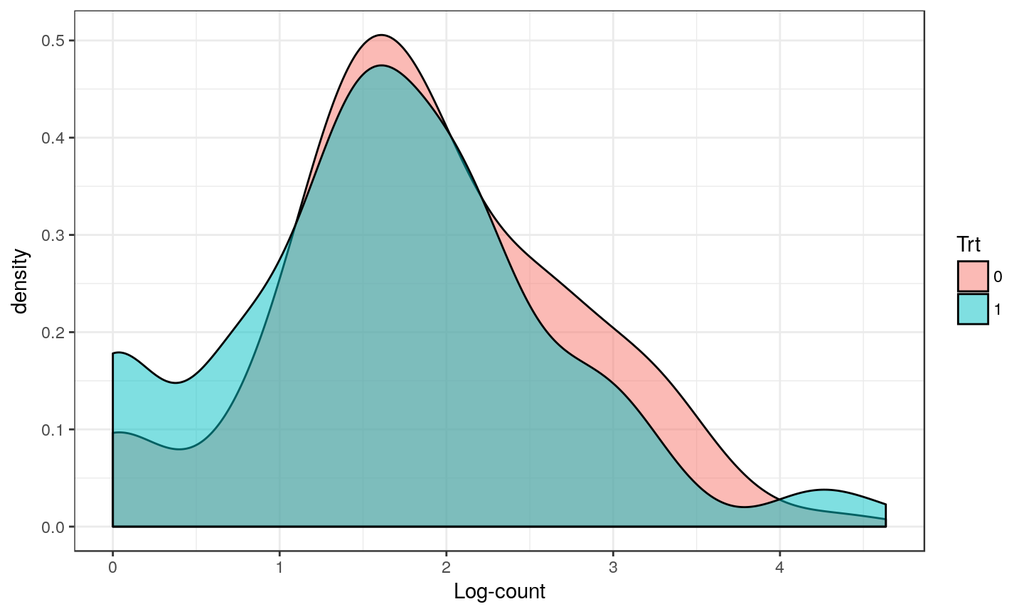

## What?

## Regression

We will, as usual be attempting to predict an outcome of interest (`count`) from covariates. For this purpose, we'll be looking at linear models and different approaches to statistical inference for those models

## Approaches to statistical inference

- Maximum Likelihood inference
- Bayesian inference
- Other stuff?

## Maximum Likelihood

## Bayesian approach

## Obligatory slide on Bayes rule

\[p(\theta|\mathcal{D}) = \frac{p(\mathcal{D}|\theta)p(\theta)}{p(\mathcal{D})}\]

which breaks down to:  
* \(p(\theta|\mathcal{D})\): the posterior distribution over parameters (\(\theta\)) given our data (\(\mathcal{D}\)) * \(p(\mathcal{D}|\theta)\): The likelihood – the probability of our data given the parameters * \(p(\theta)\): the prior probability of our parameters before we see the data * \(p(\mathcal{D})\): the evidence – the probability of our data integrating over all possible sets of parameters

## Methods not appearing in this talk

- Maximum entropy methods
- Mechanistic models
- Assorted ad-hoc stuff

## Why?

## Quantifying Uncertainty

Our general goal in statistics is to allow reasoning under uncertainty. A big advantage of bayesian methods is that they make explicit the assumptions we're making about this uncertainty. This means:

- We're letting ourselves make probabilistic statements about parameters
- We get some nice probabilistic statements about our predictions for free(-ish)
- Confidence intervals mean something fairly intuitive

## Point estimates vs. distributions

- The results of a maximum likelihood estimator are a single point estimate.
- While the point estimate may be the best estimate for some given definition of best, there are often nearly-as-good estimates available to us
- Point estimates can be unstable depending on our data

## Interpretability

- A 95% confidence* interval in this context is a statement that we expect the parameter/prediction/function of our prediction to fall within these bounds with 95% probability (given our model)

## Incorporating prior information

## Brief note on updating models

A lot of materials on Bayesian methods mention the cool way you can use Bayes rule to update your model given new information

- For practical computations, this is limited to certain classes of model

## How?

## Obligatory slide on Bayes rule (again)

\[p(\theta|\mathcal{D}) = \frac{p(\mathcal{D}|\theta)p(\theta)}{p(\mathcal{D})}\]

which breaks down to:  
* \(p(\theta|\mathcal{D})\): the posterior distribution over parameters (\(\theta\)) given our data (\(\mathcal{D}\)) * \(p(\mathcal{D}|\theta)\): The likelihood – the probability of our data given the parameters * \(p(\theta)\): the prior probability of our parameters before we see the data * \(p(\mathcal{D})\): the evidence – the probability of our data integrating over all possible sets of parameters

## Calculus is hard

- The numerator of Bayes rule is pretty straightforward, but the denominator involves a complicated and often intractable integral.
- We solve this by using approximate inference methods. Here we'll be using Markov Chain Monte Carlo methods
  - These methods take advantage of the fact that \(p(\theta|\mathcal{D}) \propto p(\mathcal{D}|\theta)p(\theta)\) which lets us solve the whole thing by just drawing random samples and then doing arithmetic on the samples.

You might also encounter:

- Numerical integration
- Variational approximations
- The Integrated Nested Laplace Approximation (INLA)
- Model-specific tools (e.g. Kalman filters)
- Assorted ad-hoc things

## Using `brms`

- User-friendly wrapper around the `stan` language
- Supports a *very* wide range of models specified using R-style model formulas
- Includes excellent tools for analyzing models
- Is a good starting point even if you end up wanting to do something more complex

## Basic model

## Regularization

By choosing an appropriate prior distribution for our parameters, we can get behavior (mostly) equivalent to regularization methods, but with well-calibrated confidence intervals

- A gaussian prior is equivalent to ridge regression (l1 regularization)
- A laplace prior is equivalent to lasso regularization
- Horseshoe and spike-and-slab priors give sparse solutions like lasso but aim to not shrink the non-zero betas the same way lasso does

## More complicated approaches

- Mixed models (and adaptive regularization)
- Additive models ()
- Measurement error models